# Forecasting payment terminals failure

## Project summary

Say the company we work for manufactures and sells electronic devices in a B2B context while offering after sales services. In some sectors, shutdown time might be extremely costly for clients and handling device reparations requires maintening a sufficient stock of spare parts at hand. Yet, producing and storing those parts comes with a cost which is why inventory levels should be about just high enough to cover the demand. This project explores the idea of quantifying and forecasting the occurence of device failures and therefore the future reparation needs using as input historical data on product sales and reparations (as a proxy for failure occurences).

Literature reviews on the topic (Auweraer, Boute, and Syntetos 2019; Dekker et al. 2013) stress the poor performence of traditional time series forecasting methods for the task of predicting spare parts demand. A first challenge is that the occurence of failures is erratic and intermitent. Another is that our expectations on the number of failures should obviously take into account the number of devices currently on the market, which we will refer to as the *installed base*, as well as its expected evolution, rather than naïvely extrapolating patterns observed in historical failure data.

The method explored here consists in three steps: First, a time-to-failure probability distribution will be estimated for each device part and failure type based on historical failure data. In a second phase, a forecast of future failures is performed based on the current state of the installed base by exploiting the fact that the expected number of part failures in time t is the sum of the individual probabilities to fail in time t for all parts in service. Finally, the exercise will be repeated in a setting where the future size and composition of the installed base is estimated.

### Literature takeaways

The proposed method follows the literature’s recommendations to think of the installed base as the driving factor for failures and therefore to exploit its current but also future state for the purpose of building expectations on future failures. Besides, it follows the subset of this literature that estimates time-to-failure probability distributions for each particular product instead of single-point estimates. What distinguishes the present attempt is the use of a non-parametric density estimation technique to build these probability distributions while generally a specific distribution is assumed. I also explore how statistical information can be combined with business knowledge to build pragmatic expectations on the future evolution of the installed base.

## Data generation

The two datasets used as source for the analysis are generated for the purpose of this project.

### Reparation data

Part-specific life-at-failure probability distributons were used to generate failures. These distributions were obtained by combining together skewed normal, truncated normal and uniform distributions so that methods based on the normality assumption or other simplifying assumptions should not be misleadingly validated.

We get:

```r
failures_df %>%
  head(100) #%>%
```

| terminal_model | nr_terminals | part_code | part | failure_description | lifetime_at_failure |
| --- | --- | --- | --- | --- | --- |
| a | 2000 | K01 | Keyboard | Key not responding | 26.746696 |
| a | 2000 | K01 | Keyboard | Key not responding | 72.351394 |
| a | 2000 | K01 | Keyboard | Key not responding | 2.467579 |
| a | 2000 | K01 | Keyboard | Key not responding | 38.363304 |
| a | 2000 | K01 | Keyboard | Key not responding | 47.193261 |
| a | 2000 | K01 | Keyboard | Key not responding | 23.129358 |
| a | 2000 | K01 | Keyboard | Key not responding | 28.552073 |
| a | 2000 | K01 | Keyboard | Key not responding | 43.185041 |
| a | 2000 | K01 | Keyboard | Key not responding | 1.110337 |
| a | 2000 | K01 | Keyboard | Key not responding | 82.387066 |

[output cut: 90 more lines]

```r
  #datatable()
```

### Sales data

Say 2000 devices of model A and 1000 devices of model B were sold between January 01 2017 and December 31 2019.

The dataset is generated as follows: First, a sequence of consecutive dates from January 01 2017 and December 31 2019 is generated. Then a sample of size 2000 + 1000 is drawn with replacement from this sequence. Some seasonality is deliberately created by the fact that at each stochastic iteration, the relative probability for a given date in the sequence to be picked depends on its position in the calendar year.

```r
sales_df %>%
  head(100)
```

| device_model | date_sold | sales |
| --- | --- | --- |
| A | 2017-01-08 | 1 |
| A | 2017-01-09 | 3 |
| A | 2017-01-10 | 1 |
| A | 2017-01-12 | 1 |
| A | 2017-01-13 | 1 |
| A | 2017-01-15 | 1 |
| A | 2017-01-17 | 1 |
| A | 2017-01-18 | 2 |
| A | 2017-01-19 | 3 |
| A | 2017-01-20 | 1 |

[output cut: 90 more lines]

## Exploration and density estimation

Now let’s start exploring the reparation dataset as if we didn’t know its generating process. First we’re interested in understanding the lifetime at which failures generally occur. Here we visualize the frequency of the devices lifetime at failure for 3 failures type and 3 different device parts.

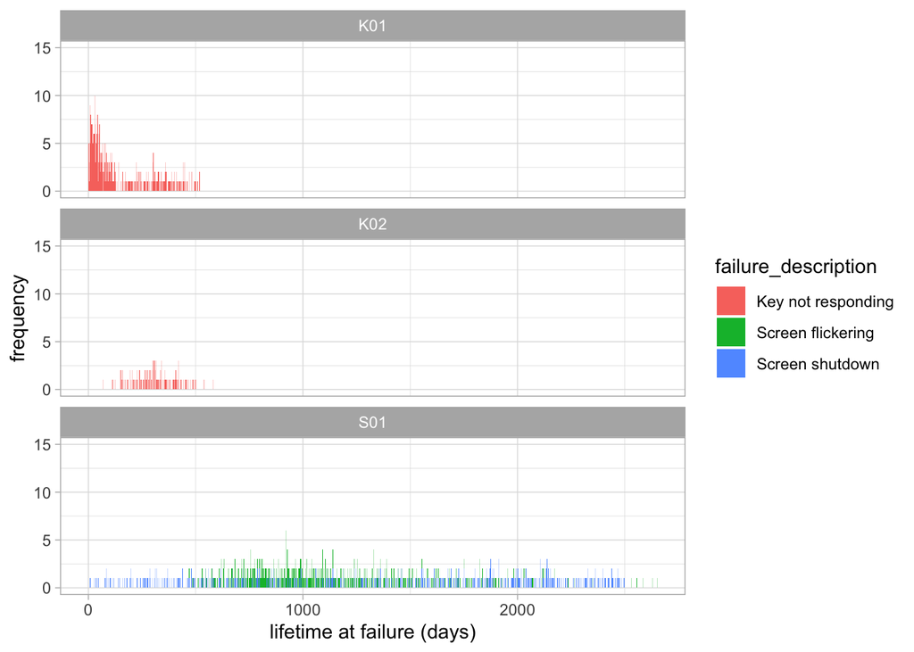

```r
(p0 <- failures_df %>%
  ggplot(aes(lifetime_at_failure)) + geom_histogram(aes(fill=failure_description), binwidth = 1) +
  facet_wrap(~part_code, ncol = 1) +
  theme_light()  + ylab("frequency") + xlab("lifetime at failure (days)") +
  ylim(0,15))
```

We already see some interesting patterns here, for example a lot of failures are recorded in the first 60 days of life for the part *K01*, followed by a second wave centered around 300 days of life. On the other hand, the “screen shutdown” seems to occur at any time of the device’s life. A way to make more sense of these spiky frequencies is to estimate failure-specific density distributions based on this information. The obtained density distributions will have two advantages:

- get a smooth distribution of when failures are likely to occur by getting rid of uninformative spikes;
- get a vector of (relative) failure probabilities instead of frequencies. This is what we’ll need for the forecasting part.

```r
# 1. Nest dataset so that each value in the column "data" is actually a 2-columns dataframe that records for each failure the lifetime at which it occured and the total number of devices from the corresponding model in the installed base.

(failures_df_nested <- failures_df %>%
  select(-terminal_model) %>%
  group_by(part, part_code, failure_description) %>%
  nest())
```

| part | part_code | failure_description | data |
| --- | --- | --- | --- |
| Keyboard | K01 | Key not responding |  |
| Screen | S01 | Screen flickering |  |
| Screen | S01 | Screen shutdown |  |
| Keyboard | K02 | Key not responding |  |

A function will be applied that returns for each pair (*part*; *failure type*) a probability distribution in the part’s time-to-failure. While the observed lifetime at failure will be used to estimate time-to-failure densities, ratio $Nr(failed)/Nr(sold)$ will be used to weigh down these densities so that they integrate to the likelihood that corresponding failure occurs instead of one.

```r
# Non-censored case
get_weighted_density_df <- function(df) {
  shareofpopulation = length(df[["lifetime_at_failure"]])/max(df[["nr_terminals"]])
  kdensity <- density(df[["lifetime_at_failure"]], bw = "nrd0", kernel = "gaussian", from=0, to=3000, n =3001)
  data.frame(
    life_length = kdensity$x,
    weighted_density = kdensity$y * shareofpopulation
  )
}

# Censored durations case
get_weighted_presmooth_density_df  <- function(df) {
  shareofpopulation = length(df[["lifetime_at_failure"]])/max(df[["nr_terminals"]])
  kdensity <- presmooth(times = df[["lifetime_at_failure"]], status = rep(1,length(df[["lifetime_at_failure"]])), estimand = "f", x.est = seq(0,3000, by=1), bw.selec = "plug-in")
  data.frame(
    life_length = kdensity$x.est,
    weighted_density = kdensity$estimate * shareofpopulation
  )
}

failures_densities_df_nested <- failures_df_nested %>%
  mutate(density_est = map(data, get_weighted_presmooth_density_df)) %>%
  select(-data)
```

Unlike a parametric density estimation method, the kernel density estimator is highly flexible which makes it able to fit the heterogeneous types of empirical distributions we could potentially encounter.

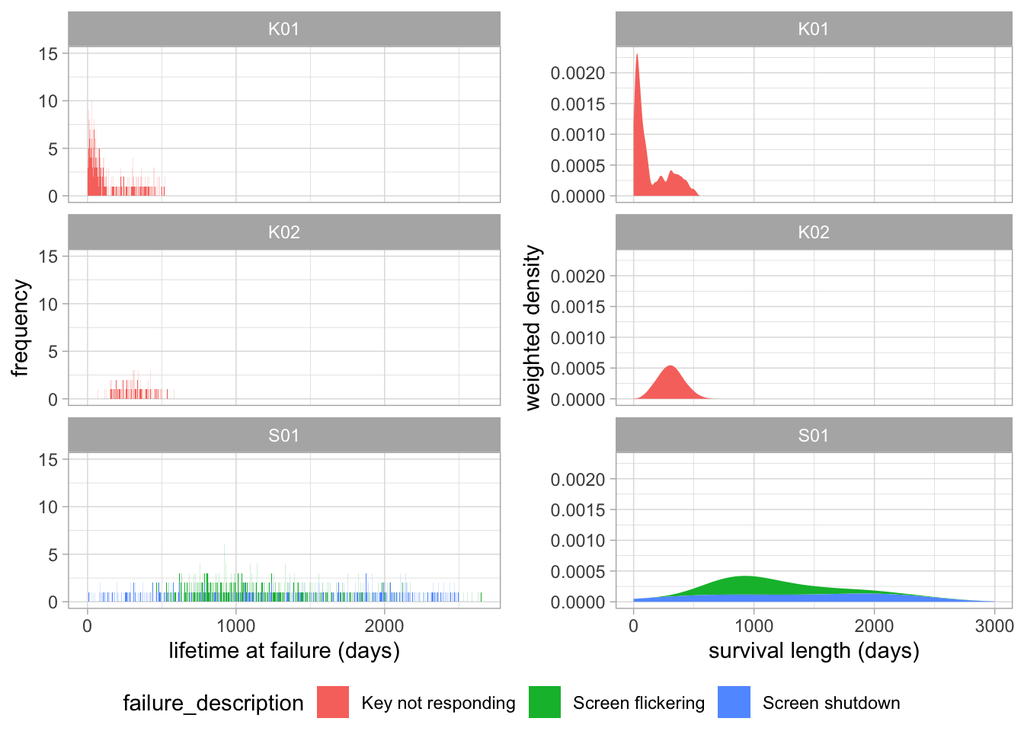

```r
failures_densities_df <- unnest(failures_densities_df_nested)

p1 <- failures_densities_df %>%
  ggplot(aes(life_length, weighted_density, fill= failure_description)) +
  geom_area(alpha= 1) +
  facet_wrap(~part_code, ncol = 1) +
  ylab("weighted density") + xlab("survival length (days)") +
  theme_light()

ggpubr::ggarrange(p0, p1, common.legend = TRUE, ncol = 2, legend = "bottom")
```

Now that we have estimated a time-to-failure probability distribution for each part, we can add them up to get that of device A and B.

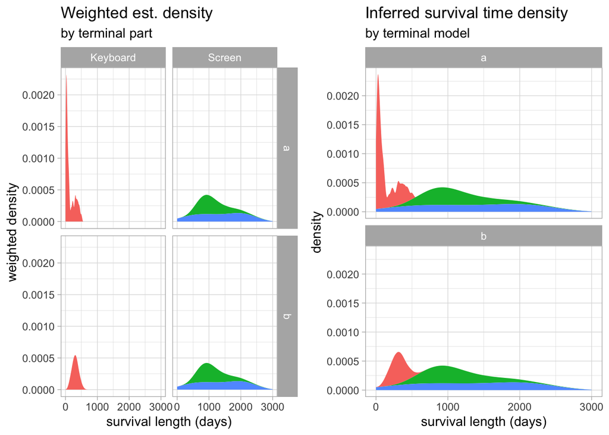

```r
failure_densities_bydevice_nested <- terminals_df %>%
  left_join(failures_densities_df_nested)


failure_densities_bydevice <- failure_densities_bydevice_nested %>%
  unnest()


p2 <- failure_densities_bydevice %>%
  ggplot(aes(life_length, weighted_density, fill= failure_description)) +
  geom_area() +
  facet_grid(terminal_model ~ part) +
  guides(fill = FALSE) +
  labs(title = "Weighted est. density", subtitle = "by terminal part", y = "weighted density", x = "survival length (days)") +
  theme_light()



p3 <- failure_densities_bydevice %>%
  ggplot(aes(life_length, weighted_density)) +
  geom_area(aes(fill = failure_description)) +
  guides(fill = FALSE) +
  labs(title = "Inferred survival time density", subtitle = "by terminal model", y = "density", x = "survival length (days)") +
  theme_light() +
  facet_wrap(~terminal_model, ncol = 1)

gridExtra::grid.arrange(p2, p3, ncol = 2, nrow = 1)
```

Obtaining these device-specific lifetime probability distributions is the first step towards forecasting the occurence of failures. In what follows we’ll see how these vectors of probabilities can be used for that purpose.

## Failure forecasting

Let’s first illustrate the method for forecasting the failures of the current installed base – i.e. the pool of devices that have already been sold at the time the forecast is performed – and then discuss why the solution should be complemented with sales forecasts to really provide worthwile results.

### Static installed base setting

In the previous section, we estimate part-specific density functions, $\hat f_j(\tau)$ in their time-to-failure $\tau$. We then weight them down before showing how we can use them to infer a failure probability function for each device model. If we denote by $\alpha_j$ the probability that a device containing the part $j$ fails due to part $j$, the estimated time-to-failure probability distribution of device $i$ containing the set of parts $J_i$ is:
$$\hat g_i(\tau) = \sum_{j \in J_i} \alpha_j \hat f_j(\tau)$$

where the weights ensure that $\int_{\tau=1}^{T} \hat g_i(\tau) = \sum_{j \in J} \alpha_j = \alpha_i$ i.e. that the failure rate of the device $i$ is the sum of the failure rate of its parts.

Now we will use these device-specific densities in parallel with the sales data to compute the flow of failures by building on the following principle.

$$E \Big[ Nr(failure)_t \Big] = \sum_{i=1}^n \hat g_i(\tau_i, t) = \sum_{i=1}^n \sum_{j \in J_i} \alpha_j \hat f_j(\tau)$$
In other words, by adding up the part-specific weighted densities while appending them to the timeline so that $\tau = 0$ at the corresponding device’s selling date, we’ll obtain the expected number of failures at each point in time. As a first step we join the sales data with the dataframe containing our estimations to obain a dataset where each row defines a part sold at a given date together with the related estimated life-at-failure probability distribution.

```r
df <- data.frame(
  device_model = c(rep("A", length(parts_a)), rep("B", length(parts_b))),
  part_code = c(parts_a,parts_b)
)

forecast_nested <- sales_df %>%
  left_join(df, by = "device_model") %>%
  left_join(failure_densities_bydevice_nested, by = "part_code") %>%
  select(-c(nr_terminals,terminal_model))

forecast_nested %>%
  head(100)
```

| device_model | date_sold | sales | part_code | part | failure_description | density_est |
| --- | --- | --- | --- | --- | --- | --- |
| A | 2017-01-08 | 1 | K01 | Keyboard | Key not responding |  |
| A | 2017-01-08 | 1 | S01 | Screen | Screen flickering |  |
| A | 2017-01-08 | 1 | S01 | Screen | Screen shutdown |  |
| A | 2017-01-08 | 1 | S01 | Screen | Screen flickering |  |
| A | 2017-01-08 | 1 | S01 | Screen | Screen shutdown |  |
| A | 2017-01-09 | 3 | K01 | Keyboard | Key not responding |  |
| A | 2017-01-09 | 3 | S01 | Screen | Screen flickering |  |
| A | 2017-01-09 | 3 | S01 | Screen | Screen shutdown |  |
| A | 2017-01-09 | 3 | S01 | Screen | Screen flickering |  |
| A | 2017-01-09 | 3 | S01 | Screen | Screen shutdown |  |

[output cut: 90 more lines]

Now we have to find a way to plug each of these probability vectors at the right place on the timeline i.e. make sure that $\tau_j=0$ where $t=date\_sold_j$** for all parts $j$, before adding them up to get the expected total number of failures throughtout time. The following function will do exactly that:

```r
get_timelinedf = function(start_date, df){

  # compute nr of zero values to append to the values vector
  nr_zero <- max(as.numeric(difftime(as.Date("2025/01/01"), as.Date(start_date),"days")) - length(df[["weighted_density"]]) + 1, 0)

  # create output df
  data.frame(
    timeline = seq(from = as.Date(start_date), to = as.Date("2025/01/01"), by ="days"),
    values = head(
      append(df[["weighted_density"]], rep(0,nr_zero)),
      as.numeric(difftime(as.Date("2025/01/01"), as.Date(start_date),"days")) +1 )
  )
}
```

Now we can aggregate these results per date and get our part failure forecast.

```r
forecast_df <- forecast_nested %>%
  mutate(expected_failure = map2(date_sold, density_est, get_timelinedf)) %>%
  select(-density_est) %>%
  unnest() %>%
  group_by(timeline, failure_description) %>%
  summarise(values = sum(values))
```

Note that the fact that we have kept the granularity at the failure description level enables the prediction not only of the number of failures but also of the reason for those failures. This might be important if the goal is to manage spare parts inventories or to disinguish between demand for reparation and demand for replacement.

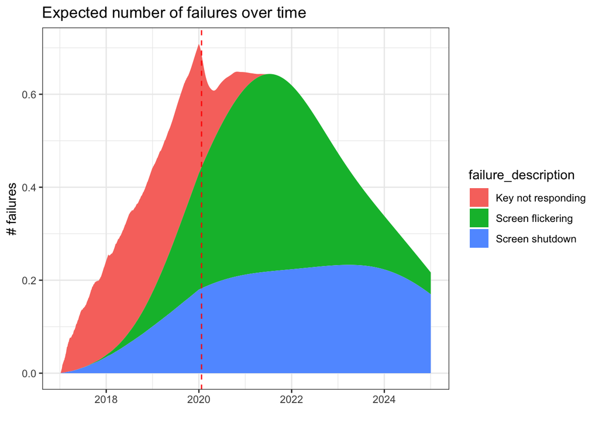

```r
forecast_df %>%
  ggplot(aes(timeline,values)) +
  geom_area(aes(fill = failure_description)) +
  labs(title = "Expected number of failures over time", y="# failures", x="") +
  theme_bw() +
  geom_vline(xintercept=Sys.Date(), linetype="dashed", color = "red")
```

```r
# add vertical line at today's date
```

### Evolving installed base setting

While forecasting the failures for the current installed base might be a realistic objective in the context of an end-of-life product, it is clear that the sales might continue, or even grow in the future. In this context, our model should be extended to take into account the fact that the installed base will keep evolving in terms of size and composition in the future.

#### Sales data analysis

To integrate the notion of an evolving installed base, all we need is to enrich the historical sales data with product-specific sales forecasts. My opinion is that the main part of this forecast must come from business experts, which is why I would exclude any purely statistical (time series forecasting) approach. However, I will explore how the business knowledge of future trends might be combined with seasonal patterns that we can extract from historical sales data in a hybrid approach.

Say our sales data look like this:

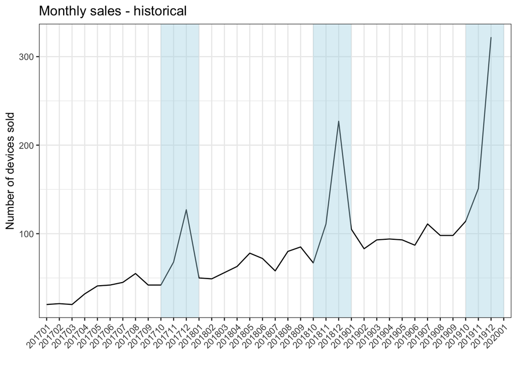

```r
sales_df_monthly <- sales_df %>%
  group_by(device_model, yearmonth = strftime(date_sold, "%Y%m"), year = strftime(date_sold, "%Y"), month = strftime(date_sold, "%m")) %>%
  summarize(monthly_sales = sum(sales)) %>%
  arrange(year, month)

peaks <- data.frame(
  start = paste(seq(min(sales_df_monthly$year), max(sales_df_monthly$year),1),"10", sep=""),
  end = as.character(as.numeric(paste(seq(min(sales_df_monthly$year), max(sales_df_monthly$year) ,1),"01", sep="")) + 100)
)

sales_df_monthly %>%
  filter(device_model == "A") %>%
  ggplot(aes(yearmonth, monthly_sales)) +
  geom_line(aes(group=1)) +
  theme_bw() +
  theme(axis.text.x = element_text(angle = 45, hjust = 1))+
  geom_rect(data = peaks, aes(xmin = start , xmax = end, ymin = -Inf, ymax = Inf),
            inherit.aes=FALSE, alpha = 0.4, fill = c("lightblue")) +
  labs(title = "Monthly sales - historical", x = "", y = "Number of devices sold")
```

There is obviously some seasonality in the sales: client orders tend to be higher in the last two months of the year. It also seems that sales tend to increase over time. In what follows we use a multiplicative model to extract the cylical component from this series. Our goal will be to exploit it in the forecasting of future sales while letting the business figure out a plausible trend for each product’s sales in the comming years.

#### sales forecast

```r
# Parameter:
forecast_length_years = 2
yearly_growth_A = -.3

failures_A_series <- sales_df_monthly %>%
  filter(device_model == "A")

# Variables:
length_observed <- length(failures_A_series$yearmonth)
forecast_length_months = forecast_length_years*12
monthly_growth_A = (1+yearly_growth_A)^(1/12)
```

A simple linear forecast would look like:

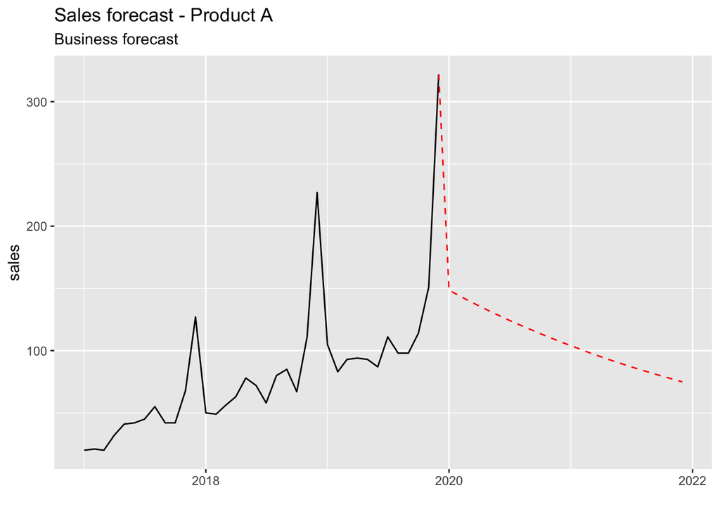

```r
df <- failures_A_series %>%
  mutate(yearmonthday = ymd(paste(yearmonth, "01", sep = "")))

ts_A<-ts(failures_A_series$monthly_sales, frequency =12, start= c(year(startdate), day(startdate)))
ts_A_model<- decompose(ts_A, "multiplicative")


# append df to get a forecast df
last_date <- tail(df$yearmonthday , 1)
last_sales <- tail(df$monthly_sales, 1)

df2 <- data.frame(
  device_model = c(df$device_model, rep(df$device_model[1], forecast_length_months)),
  yearmonth = c(df$yearmonthday, seq(from = ymd(last_date) + months(1), length.out = forecast_length_months, by= "month")),
  sales = c(df$monthly_sales, rep(NA,forecast_length_months))
)


# Get starting point
trendmodel <- lm(sales~ yearmonth, df2)
df2 <- df2 %>%
  add_predictions(trendmodel, "pred_trendmodel")
start_pred_business <- df2$pred_trendmodel[length_observed + 1]

df3 <- data.frame(
  device_model = df2$device_model,
  yearmonth = df2$yearmonth,
  sales = df2$sales,
  forecast_business = c(rep(NA, length_observed -1),
                        last_sales,
                        start_pred_business*cumprod(rep(monthly_growth_A, forecast_length_months))),
  seasonality = c(rep(1,length_observed), rep(head(as.numeric(ts_A_model$seasonal), 12),forecast_length_years))
) %>%
  mutate(month = months(yearmonth), forecast_business_seasonalized = forecast_business* seasonality)

df3 %>%
  ggplot() +
  geom_line(aes(x = yearmonth, y = sales)) +
  geom_line(aes(x = yearmonth, y = forecast_business), color = "red", linetype = "dashed") +
  labs(title = "Sales forecast - Product A", subtitle = "Business forecast", x = "")
```

And enriching it with the seasonality we estimated from past data, we can make it look like:

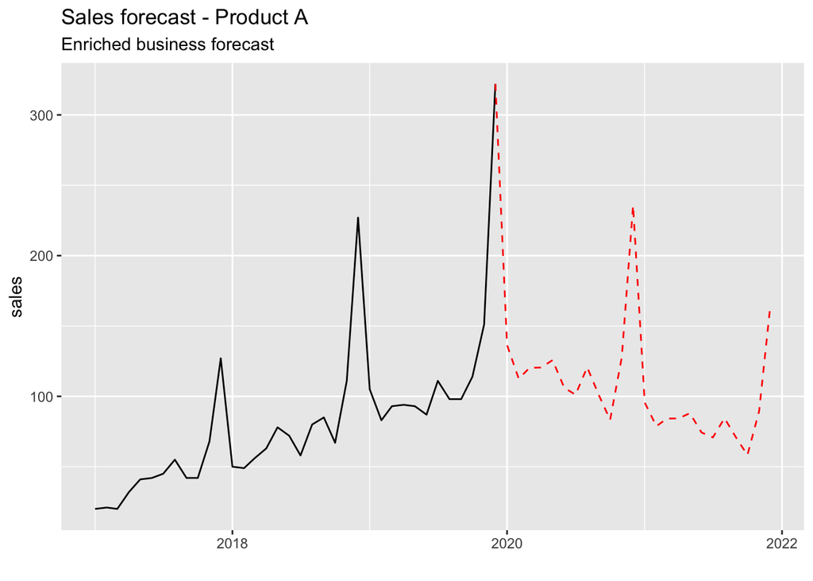

```r
df3 %>%
  ggplot() +
  geom_line(aes(x = yearmonth, y = sales)) +
  geom_line(aes(x = yearmonth, y = forecast_business_seasonalized), color = "red", linetype = "dashed") +
  labs(title = "Sales forecast - Product A", subtitle = "Enriched business forecast", x = "")
```

## References

Auweraer, Sarah Van der, Robert N Boute, and Aris A Syntetos. 2019. “Forecasting Spare Part Demand with Installed Base Information: A Review.” *International Journal of Forecasting* 35 (1). Elsevier: 181–96.

Dekker, Rommert, Çerağ Pinçe, Rob Zuidwijk, and Muhammad Naiman Jalil. 2013. “On the Use of Installed Base Information for Spare Parts Logistics: A Review of Ideas and Industry Practice.” *International Journal of Production Economics* 143 (2). Elsevier: 536–45.